# hw4

Your Name

2016年10月5日

## Q25

### 解题思路：

1. 初始化设定x=0，时间T=0；
2. 利用sample抽样从{-1，1}抽样，每个数字被抽取的概率均为50%，抽取的数值记为a，同时时间T+1
3. 判断x+a是否小于10，如果小于10，则继续循环，当x+a等于10的时候，停止循环并输出时间T。

### 结论

1. 将上诉过程模拟200次，产生200个时间T。其中最小的T为14，最大为649300。
2. 1st Qu 为80，中位数为263，3rd Qu为926.
3. 为了合适的展示boxplot，将纵坐标限制在0~3000之间。

```r
# 定义q25的模拟过程。求出当X第一次等于10的时间T
s25 <- function(){
     T <-0 # 初始化时间T
     x <- 0 # 初始化x
     while(x<10){ # 设定循环过程，如果X小于10，则继续循环，直到当X第一次等于10的停止循环。
        a <- sample(x = c(1,-1),size = 1,prob = c(0.5,0.5))
        x <- x + a # 按照transition probabilities，求出下一步的X值
        T <- T +1 # 时间T递增+1
     }
return(T)
}
# Use a simulation to generate a few hundred values of T
set.seed(25)
T <- replicate(n = 200,expr = s25())
#the box plot and  a description(max, min, quartiles, median).
summary(T)
```

```
##    Min. 1st Qu.  Median    Mean 3rd Qu.    Max.
##      14      80     263   13700     926  649300
```

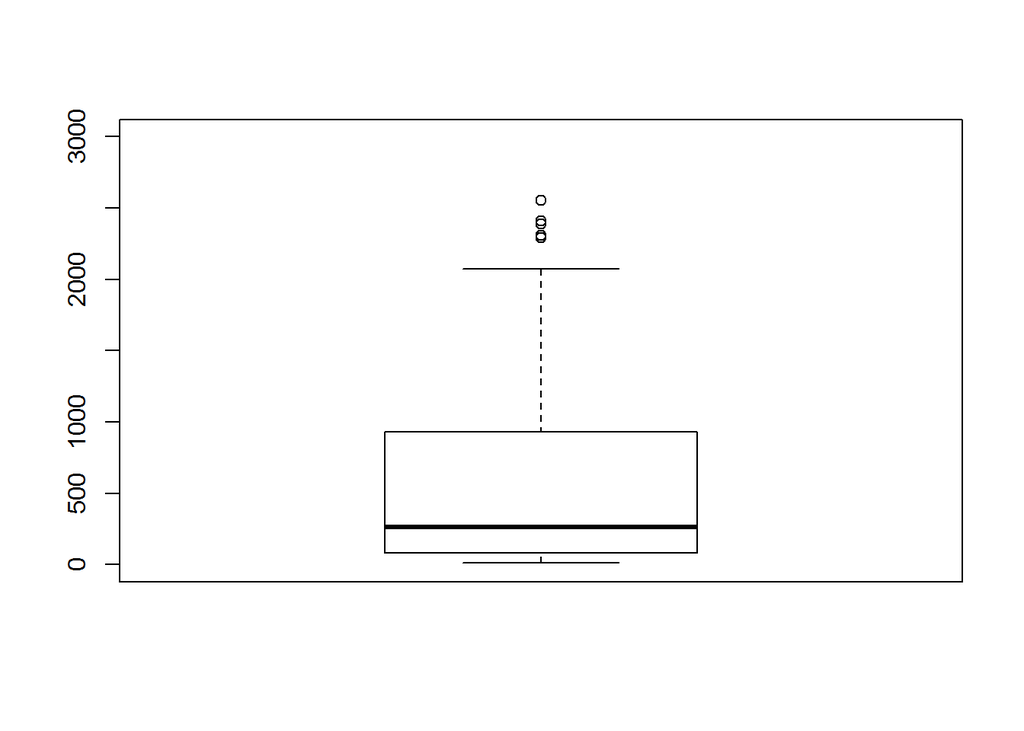

```r
boxplot(T,ylim=c(0,3000))
```

## Q26

这里不知道是什么意思。。。。。你自己写点吧。。

## Q27

当JOE betting $1 on red numbers成功的时候，记为`{R=T}`,失败时为`{R=F}`。当 betting $1 on odd numbers成功的时候，记为`{O=T}`,失败时记为`{O=F}`

因此，All possible outcomes of a single game and their probabilities：

$$\begin{aligned}
P\{R=T,O=T\} = \frac{10}{38}
\end{aligned}$$
$$\begin{aligned}
P\{R=T,O=F\} = \frac{8}{38}
\end{aligned}$$
$$\begin{aligned}
P\{R=F,O=T\}= \frac{8}{38}
\end{aligned}$$
$$\begin{aligned}
P\{R=F,O=F\}= \frac{12}{38}
\end{aligned}$$

its expected value:

$$\begin{aligned}
E(X) = \sum_{R,O \in(T,F)} P\{R,O\} \cdot X = \frac{10}{38} * 3 + \frac{8}{38} * 1 + \frac{8}{38} * 2 + \frac{12}{38} * 0 \approx 1.421
\end{aligned}$$

## Q28

**这里感觉题目有问题或者就是我理解不对，1<=j,k<=n感觉不对，应该是1<=j,k<=n^2 ,我解释的也不太好，你参考就好了**

NOT TRUE:

假设当n=3的时候，一共会有3*3=9tiles，按照如下标记每个tile。

```r
matrix(1:9,nrow = 3)
```

```
##      [,1] [,2] [,3]
## [1,]    1    4    7
## [2,]    2    5    8
## [3,]    3    6    9
```

当k=2，j=1的时候分别有：
$$\begin{aligned}
P(X_{i+1}=2 |X_i = 1) = \frac{1}{2}
\end{aligned}$$
$$\begin{aligned}
P(X_{i+1}=1 |X_i = 2) = \frac{1}{3}
\end{aligned}$$

因此可以得出：
$$\begin{aligned}
P(X_{i+1}=1 |X_i = 2)\neq P(X_{i+1}=2 |X_i = 1)
\end{aligned}$$

## Q29

the joint probability mass function (pmf) for X and Y :

$$\begin{aligned}
P\{X=k,Y=j\} = \frac{1}{n} \cdot C^j_k \cdot p^j \cdot(1-p)^{k-j} \ \ j \leq k \leq n
\end{aligned}$$

## Q30

### loading transition matrix

将transition matrix写入CSV文件，然后使用R语言读取文件，这样做是方便操作。

```r
tm <- as.matrix(read.csv(file = 'C://Users//AomoDa//Documents//q30.csv',header = F))
colnames(tm) <- 1:9
round(tm,3)
```

```
##           1     2     3     4     5     6     7     8     9
##  [1,] 0.500 0.250 0.000 0.250 0.000 0.000 0.000 0.000 0.000
##  [2,] 0.167 0.500 0.167 0.000 0.167 0.000 0.000 0.000 0.000
##  [3,] 0.000 0.250 0.500 0.000 0.000 0.250 0.000 0.000 0.000
##  [4,] 0.167 0.000 0.000 0.500 0.167 0.000 0.167 0.000 0.000
##  [5,] 0.000 0.125 0.000 0.125 0.500 0.125 0.000 0.125 0.000
##  [6,] 0.000 0.000 0.167 0.000 0.167 0.500 0.000 0.000 0.167
##  [7,] 0.000 0.000 0.000 0.250 0.000 0.000 0.500 0.250 0.000
##  [8,] 0.000 0.000 0.000 0.000 0.167 0.000 0.167 0.500 0.167
##  [9,] 0.000 0.000 0.000 0.000 0.000 0.250 0.000 0.250 0.500
```

### a

结算结果可以由以下代码计算出：

$$\begin{aligned}
P(X_3 = 3 | X_0 = 1) = 0.0625
\end{aligned}$$

```r
init <- matrix(data = c(1,rep(0,8)),nrow = 1)
round(init %*%tm %*%tm %*%tm ,4)
```

```
##         1      2      3      4     5      6      7      8 9
## [1,] 0.25 0.2292 0.0625 0.2292 0.125 0.0208 0.0625 0.0208 0
```

### b

**这里感觉也是理解有问题，循环了好几百万次，找不到合适的T，也就说说明存活的概率始终是大于50%的，不论在这里面呆多久时间。**

要么就是转移矩阵不对，到底可不可以斜着走？

```r
# 代码写出来了，但是求不出T
# T <- 0
# while(st[,9]<=0.5 ) {
# if(T==0){st <- init %*% tm } else{st <- st %*% tm}
# T <- T +1
# }
```

## Q31

### a

$$\begin{aligned}
P\{N=n,X=x\} = \frac{\lambda^n}{n!} e^{-\lambda} \cdot C^x_n \cdot p^x \cdot (1-p)^{n-x}
\end{aligned}$$

### b

```r
s31 <- function(lamda,p,k=1){
   if(lamda>0 & p >0  & p <1){
        return(replicate(n=k ,expr = rbinom(n = 1,size=rpois(n = 1,lamda),prob = p)))
    }
}
s31(lamda = 10,p = 0.2,k = 10)
```

```
##  [1] 3 4 1 3 0 0 1 5 1 4
```

### c

模拟100次，每次产生100个随机数然后求得X的期望值，通过模拟不同的$\lambda$ 和p，猜想得出X的期望值为：

$$\begin{aligned}
E(x) = \lambda \cdot p
\end{aligned}$$

```r
### when lamda = 5,p = 0.7,k=100,重复100次实验
set.seed(31)
mean(replicate(n = 100,expr =mean(s31(lamda = 5,p = 0.7,k = 100)) ))
```

```
## [1] 3.5121
```

```r
### when lamda = 0.8,p = 0.5,k=100，重复100次实验
set.seed(31)
mean(replicate(n = 100,expr =mean(s31(lamda = 0.8,p = 0.5,k = 100)) ))
```

```
## [1] 0.3939
```

```r
### when lamda = 20,p = 0.5,k=100，重复100次实验
set.seed(31)
mean(replicate(n = 100,expr =mean(s31(lamda = 20,p = 0.5,k = 100)) ))
```

```
## [1] 9.9914
```

## Q32

```r
set.seed(32)
X <- rbinom(n = 10000,size = 100,prob = 0.2)
Y <- rbinom(n = 10000,size = 100,prob = 0.8)
Z <- X+Y
```

## a

using R simulations,得出的结果为：

$$\begin{aligned}
P(X <10 | X <15)=0.02648172
\end{aligned}$$
$$\begin{aligned}
E(X|X<15)=12.87137
\end{aligned}$$

```r
sum(X<15 & X < 10) / sum(X <15)
```

```
## [1] 0.02648172
```

```r
mean(X[X<15])
```

```
## [1] 12.87137
```

## b

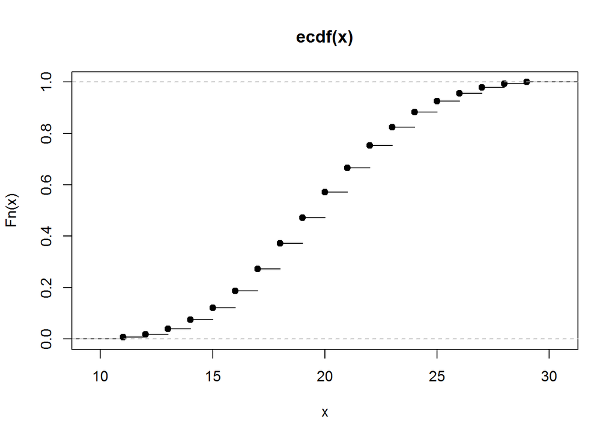

```r
plot.ecdf(X[X<30 & X>10])
```

### c

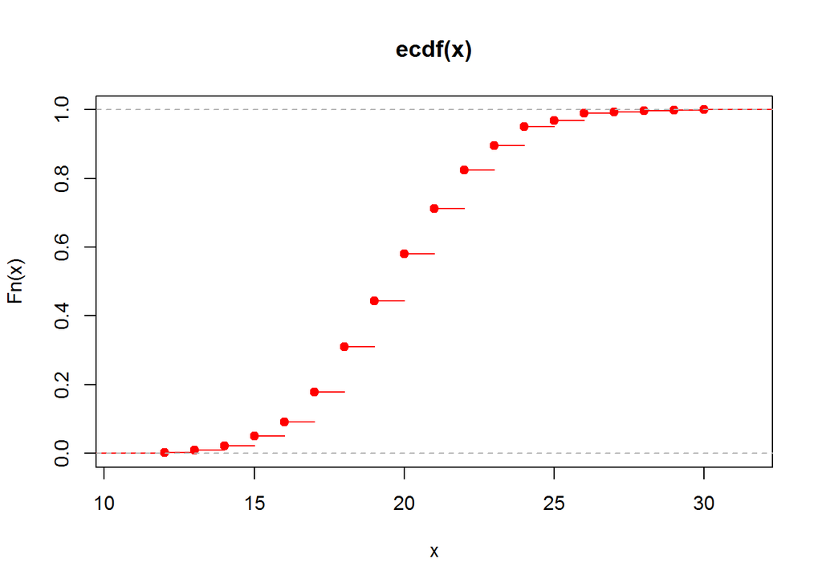

```r
plot.ecdf(X[Z==100],col='red')
```

### d

using R simulations,得出的结果为：
$$\begin{aligned}
E(Z| X =15)=95.28509
\end{aligned}$$
$$\begin{aligned}
E(Z| X =20)=99.8714
\end{aligned}$$
$$\begin{aligned}
E(Z| X =25)=104.9007
\end{aligned}$$

```r
mean(Z[X==15]);mean(Z[X==20]);mean(Z[X==25])
```

```
## [1] 95.28509
```

```
## [1] 99.8714
```

```
## [1] 104.9007
```

### e

using R simulations,得出的结果为：
$$\begin{aligned}
E(X| Z =90)=15.52229
\end{aligned}$$
$$\begin{aligned}
E(X| Z =95)=17.5511
\end{aligned}$$
$$\begin{aligned}
E(X| Z =100)=19.98074
\end{aligned}$$

```r
mean(X[Z==90]);mean(X[Z==95]);mean(X[Z==100])
```

```
## [1] 15.52229
```

```
## [1] 17.5511
```

```
## [1] 19.98074
```